# Social Uses

2017-10-31T22:26:09-05:00

# General Social Survey (GSS)

The [General Social Survey (GSS)](http://www.gss.norc.org/) gathers data on American society in order to monitor and explain trends in attitudes, behaviours, and attributes. Many trends have been tracked for decades, so one can see the evolution of attitudes, etc in American Society.

In this project I want to analyze data from the **2016 GSS sample data**, using it to estimate values of *population parameters* of interest about US adults.

```r
gss <- read_csv(here::here("data", "smallgss2016.csv"),
                na = c("", "Don't know",
                       "No answer", "Not applicable"))
```

I notice that many responses should not be taken into consideration, like “No Answer”, “Don’t Know”, “Not applicable”, “Refused to Answer”.

I will be creating 95% confidence intervals for population parameters. The variables we have are the following:

- hours and minutes spent on email weekly. The responses to these questions are recorded in the `emailhr` and `emailmin` variables. For example, if the response is 2.50 hours, this would be recorded as emailhr = 2 and emailmin = 30.
- `snapchat`, `instagrm`, `twitter`: whether respondents used these social media in 2016
- `sex`: Female - Male
- `degree`: highest education level attained

## Instagram and Snapchat, by sex

First, I want to estimate the *population* proportion of Snapchat or Instagram users in 2016

### New variable snap_insta

Create a new variable, `snap_insta` that is *Yes* if the respondent reported using any of Snapchat (`snapchat`) or Instagram (`instagrm`), and *No* if not. If the recorded value was NA for both of these questions, the value in your new variable should also be NA.

```r
gss<-gss%>%
  mutate(snap_insta=ifelse(snapchat=='Yes'|instagrm=='Yes','Yes', ifelse(snapchat=='NA'&instagrm=='NA','NA','No')))
gss
```

```
## # A tibble: 2,867 x 8
##    emailmin emailhr snapchat instagrm twitter sex    degree         snap_insta
##    <chr>    <chr>   <chr>    <chr>    <chr>   <chr>  <chr>          <chr>
##  1 0        12      NA       NA       NA      Male   Bachelor       NA
##  2 30       0       No       No       No      Male   High school    No
##  3 NA       NA      No       No       No      Male   Bachelor       No
##  4 10       0       NA       NA       NA      Female High school    NA
##  5 NA       NA      Yes      Yes      No      Female Graduate       Yes
##  6 0        2       No       Yes      No      Female Junior college Yes
##  7 0        40      NA       NA       NA      Male   High school    NA
##  8 NA       NA      Yes      Yes      No      Female High school    Yes
##  9 0        0       NA       NA       NA      Male   High school    NA
## 10 NA       NA      No       No       No      Male   Junior college No
## # ... with 2,857 more rows
```

### Calculate proportion

Calculate the proportion of Yes’s for `snap_insta` among those who answered the question, excluding NAs.

```r
excluding_NA<-gss%>%
  filter(snap_insta!='NA')
list_exluding_NA<-table(excluding_NA$snap_insta)/sum(table(excluding_NA$snap_insta))
list_exluding_NA[2]
```

```
##       Yes
## 0.3746356
```

### CI formula

Using the CI formula for proportions, construct 95% CIs for men and women who used either Snapchat or Instagram.

```r
#calculate proportion in men
men<-gss%>%
  filter(snap_insta!='NA'& sex=='Male')
list_men<-table(men$snap_insta)/sum(table(men$snap_insta))
list_men
```

```
##
##       No      Yes
## 0.681592 0.318408
```

```r
men_prop<-list_men[2]
#construct men CI
men_formula_ci <- men %>%
  summarise(count=n(),
            t_critical=qt(0.975,count-1),
            se_men_prop=sqrt(men_prop*(1-men_prop)/count),
            margin_of_error=t_critical*se_men_prop,
            men_prop_low=men_prop-margin_of_error,
            men_prop_high=men_prop+margin_of_error)
men_formula_ci
```

```
## # A tibble: 1 x 6
##   count t_critical se_men_prop margin_of_error men_prop_low men_prop_high
##   <int>      <dbl>       <dbl>           <dbl>        <dbl>         <dbl>
## 1   603       1.96      0.0190          0.0373        0.281         0.356
```

```r
#calculate proportion in women
women<-gss%>%
  filter(snap_insta!='NA'& sex=='Female')
list_women<-table(women$snap_insta)/sum(table(women$snap_insta))
list_women
```

```
##
##        No       Yes
## 0.5812744 0.4187256
```

```r
women_prop<-list_women[2]
#construct women CI
women_formula_ci <- women %>%
  summarise(count=n(),
            t_critical=qt(0.975,count-1),
            se_women_prop=sqrt(women_prop*(1-women_prop)/count),
            margin_of_error=t_critical*se_women_prop,
            women_prop_low=women_prop-margin_of_error,
            women_prop_high=women_prop+margin_of_error)
women_formula_ci
```

```
## # A tibble: 1 x 6
##   count t_critical se_women_prop margin_of_error women_prop_low women_prop_high
##   <int>      <dbl>         <dbl>           <dbl>          <dbl>           <dbl>
## 1   769       1.96        0.0178          0.0349          0.384           0.454
```

The 95% CI for men is [0.281,0.356] and for women is [0.384,0.454].

## Twitter, by education level

Estimate the *population* proportion of Twitter users by education level in 2016.

There are 5 education levels in variable `degree` which, in ascending order of years of education, are Lt high school, High School, Junior college, Bachelor, Graduate.

### Create factor variable

So, Turn `degree` from a character variable into a factor variable. Make sure the order is the correct one and that levels are not sorted alphabetically which is what R by default does.

```r
gss$degree<-factor(gss$degree,ordered = TRUE,levels = c("Lt high school", "High School", "Junior college", "Bachelor","Graduate"))
skim(gss$degree)
```

Data summary

| Name | gss$degree |
| --- | --- |
| Number of rows | 2867 |
| Number of columns | 1 |
| _______________________ |  |
| Column type frequency: |  |
| factor | 1 |
| ________________________ |  |
| Group variables | None |

**Variable type: factor**

| skim_variable | n_missing | complete_rate | ordered | n_unique | top_counts |
| --- | --- | --- | --- | --- | --- |
| data | 1469 | 0.49 | TRUE | 4 | Bac: 536, Lt : 328, Gra: 318, Jun: 216 |

### Create variable

Create a new variable, `bachelor_graduate` that is *Yes* if the respondent has either a `Bachelor` or `Graduate` degree. As before, if the recorded value for either was NA, the value in your new variable should also be NA.

```r
gss<-gss%>%
  mutate(bachelor_graduate=ifelse(degree=='Bachelor'|degree=='Graduate','Yes',ifelse(degree=='NA','NA','No')))
skim(gss$bachelor_graduate)
```

Data summary

| Name | gss$bachelor_graduate |
| --- | --- |
| Number of rows | 2867 |
| Number of columns | 1 |
| _______________________ |  |
| Column type frequency: |  |
| character | 1 |
| ________________________ |  |
| Group variables | None |

**Variable type: character**

| skim_variable | n_missing | complete_rate | min | max | empty | n_unique | whitespace |
| --- | --- | --- | --- | --- | --- | --- | --- |
| data | 1469 | 0.49 | 2 | 3 | 0 | 2 | 0 |

### Calculate proportion

Then, Calculate the proportion of `bachelor_graduate` who do (Yes) and who don’t (No) use twitter.

```r
bac_grad<-gss%>%
  filter(bachelor_graduate=='Yes'& twitter!='NA')
use_list<-table(bac_grad$twitter)/sum(table(bac_grad$twitter))
use_list
```

```
##
##        No       Yes
## 0.7668712 0.2331288
```

```r
no_prop<-use_list[1]
yes_prop<-use_list[2]
```

### Construct CI

Using the CI formula for proportions, construct two 95% CIs for `bachelor_graduate` vs whether they use (Yes) and don’t (No) use twitter.

```r
yes_formula_ci <- bac_grad %>%
  summarise(count=n(),
            t_critical=qt(0.975,count-1),
            se_yes_prop=sqrt(yes_prop*(1-yes_prop)/count),
            margin_of_error=t_critical*se_yes_prop,
            yes_prop_low=yes_prop-margin_of_error,
            yes_prop_high=yes_prop+margin_of_error)
yes_formula_ci
```

```
## # A tibble: 1 x 6
##   count t_critical se_yes_prop margin_of_error yes_prop_low yes_prop_high
##   <int>      <dbl>       <dbl>           <dbl>        <dbl>         <dbl>
## 1   489       1.96      0.0191          0.0376        0.196         0.271
```

```r
no_formula_ci <- bac_grad %>%
  summarise(count=n(),
            t_critical=qt(0.975,count-1),
            se_no_prop=sqrt(no_prop*(1-no_prop)/count),
            margin_of_error=t_critical*se_no_prop,
            no_prop_low=no_prop-margin_of_error,
            no_prop_high=no_prop+margin_of_error)
no_formula_ci
```

```
## # A tibble: 1 x 6
##   count t_critical se_no_prop margin_of_error no_prop_low no_prop_high
##   <int>      <dbl>      <dbl>           <dbl>       <dbl>        <dbl>
## 1   489       1.96     0.0191          0.0376       0.729        0.804
```

95% CIs for `bachelor_graduate` use twitter is [0.196,0.271] and don’t use twitter is [0.7290.804].

These two Confidence Intervals don’t overlap. The following graph could prove that:

```r
formula_ci_twitter<- bac_grad %>%
  mutate(prop=ifelse(twitter=='Yes',0.233,0.767))%>%
  mutate(count=n())%>%
  group_by(twitter)%>%
  summarise(t_critical=qt(0.975,count-1),
            se_prop=sqrt(prop*(1-prop)/count),
            margin_of_error=t_critical*se_prop,
            prop_low=prop-margin_of_error,
            prop_high=prop+margin_of_error,
            prop=prop)%>%
  distinct(twitter,.keep_all = TRUE)
```

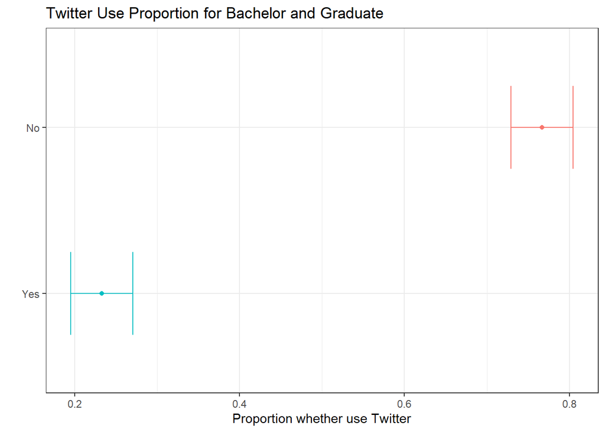

```r
ggplot(formula_ci_twitter, aes(x=reorder(twitter, prop), y=prop, colour=twitter)) +
  geom_point() +
  geom_errorbar(width=.5, aes(ymin=prop_low, ymax=prop_high)) +
  labs(x=" ",
       y= "Proportion whether use Twitter",
       title="Twitter Use Proportion for Bachelor and Graduate") +
  theme_bw()+
  coord_flip()+
  theme(legend.position = "none")+
  NULL
```

## Email usage

I want to estimate the *population* parameter on time spent on email weekly.

### Create variable

Create a new variable called `email` that combines `emailhr` and `emailmin` to reports the number of minutes the respondents spend on email weekly.

```r
gss <- gss %>%
  mutate(emailmin = as.numeric(emailmin), emailhr = as.numeric(emailhr)) %>%
  mutate(email= emailmin + emailhr * 60)
gss
```

```
## # A tibble: 2,867 x 10
##    emailmin emailhr snapchat instagrm twitter sex   degree snap_insta
##       <dbl>   <dbl> <chr>    <chr>    <chr>   <chr> <ord>  <chr>
##  1        0      12 NA       NA       NA      Male  Bache~ NA
##  2       30       0 No       No       No      Male  <NA>   No
##  3       NA      NA No       No       No      Male  Bache~ No
##  4       10       0 NA       NA       NA      Fema~ <NA>   NA
##  5       NA      NA Yes      Yes      No      Fema~ Gradu~ Yes
##  6        0       2 No       Yes      No      Fema~ Junio~ Yes
##  7        0      40 NA       NA       NA      Male  <NA>   NA
##  8       NA      NA Yes      Yes      No      Fema~ <NA>   Yes
##  9        0       0 NA       NA       NA      Male  <NA>   NA
## 10       NA      NA No       No       No      Male  Junio~ No
## # ... with 2,857 more rows, and 2 more variables: bachelor_graduate <chr>,
## #   email <dbl>
```

### Visualization

Visualise the distribution of this new variable. Find the mean and the median number of minutes respondents spend on email weekly.

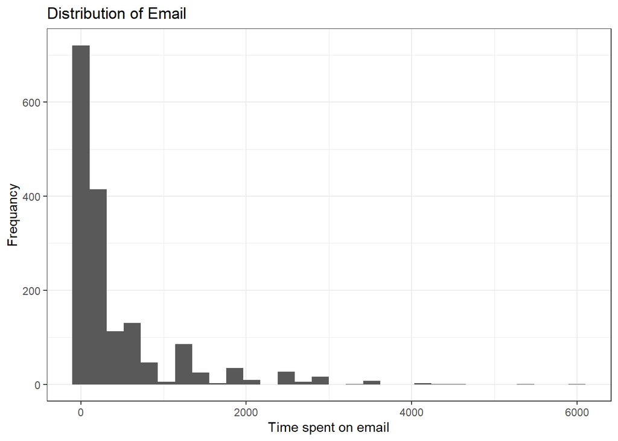

```r
gss_email <- gss %>%
  drop_na(email)

ggplot(gss_email, aes(x= email)) +
  geom_histogram() +
  theme_bw() +
  xlab("Time spent on email") +
  ylab("Frequancy") +
  ggtitle("Distribution of Email")
```

```r
summarise(gss_email, mean_mins_email =  mean(gss_email$email), median_mins_email = median(gss_email$email))
```

```
## # A tibble: 1 x 2
##   mean_mins_email median_mins_email
##             <dbl>             <dbl>
## 1            417.               120
```

Median is a better measurement to represent the typical amount of time Americans spend on email weekly. This is because there are outliers on the weekly usage of email which skewed the mean and caused the standard devation to be high.

### Calculate CI with infer

Using the `infer` package, calculate a 95% bootstrap confidence interval for the mean amount of time Americans spend on email weekly.

```r
library(infer)
gss_boot_email <- gss %>%
  drop_na(email) %>%
  specify(response = email) %>%
  generate(reps = 1000, type = "bootstrap") %>%
  calculate(stat = "mean")

email_ci <- gss_boot_email %>%
  get_confidence_interval(
    level = 0.95,
    type = "percentile",
    point_estimate = NULL
  )

email_lower_ci_hour <- email_ci$lower_ci%/%60
email_lower_ci_min <- email_ci$lower_cilower_ci%%60
email_upper_ci_hour <- email_ci$upper_ci%/%60
email_upper_ci_min <- email_ci$upper_ci%%60


paste("Lower 95% CI email usage:", email_ci$lower_ci%/%60 , "hours and", round(email_ci$lower_ci%%60, digits = 0), "minutes")
```

```
## [1] "Lower 95% CI email usage: 6 hours and 26 minutes"
```

```r
paste("Upper 95% CI email usage:", email_ci$upper_ci%/%60, "hours and", round(email_ci$upper_ci%%60, digits = 0), "minutes")
```

```
## [1] "Upper 95% CI email usage: 7 hours and 33 minutes"
```